# Categorical Predictor Homework

Calculating the emmeans and comparing them

```
## Note: Use 'contrast(regrid(object), ...)' to obtain contrasts of back-transformed estimates
```

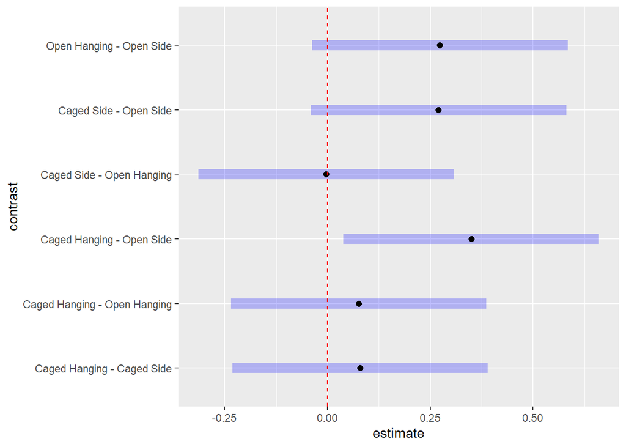

```r
cage_em <- emmeans(cage_lm_trans1, specs = ~ treatment)
contrast(cage_em, method = "pairwise")|>
  plot()+
  geom_vline(xintercept = 0, color = "red", lty = 2)
```

Plotting

```r
library(multcomp)
```

```
## Note: adjust = "tukey" was changed to "sidak"
## because "tukey" is only appropriate for one set of pairwise comparisons
```

```
## Note: Use 'contrast(regrid(object), ...)' to obtain contrasts of back-transformed estimates
```

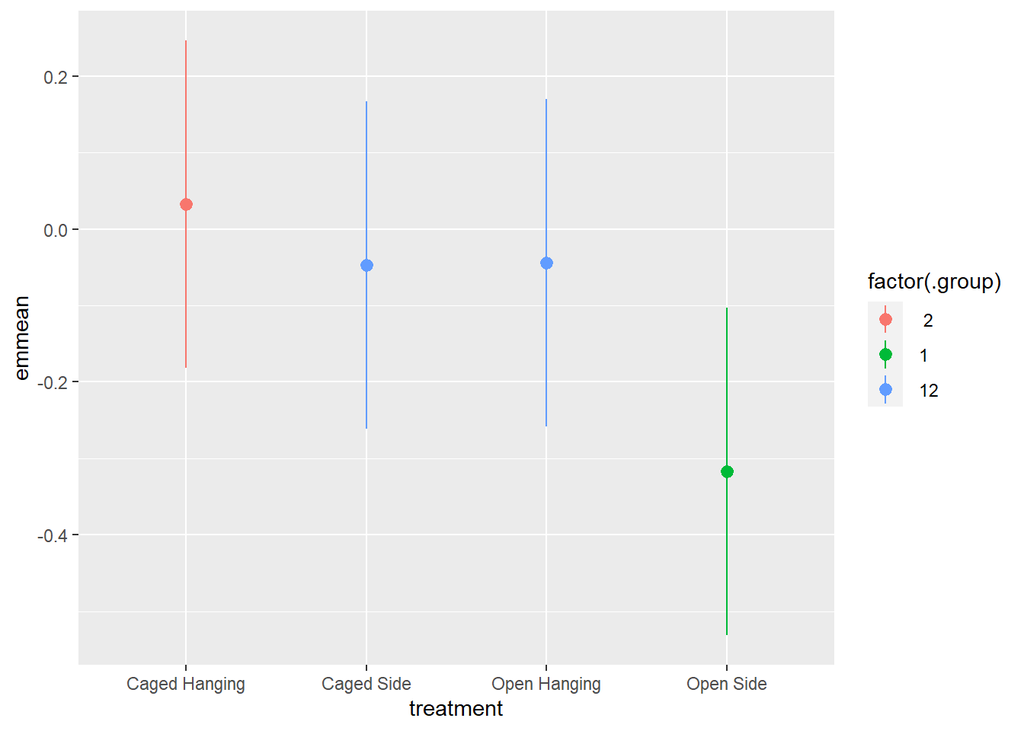

```r
cld(cage_em, adjust="tukey")|>
  ggplot(aes(x = treatment,
             y = emmean,
             ymin = lower.CL,
             ymax = upper.CL,
             color = factor(.group)))+
  geom_pointrange()
```

Meta 1: I am seeing the connection between linear regression and models with categorical variables. I think this week allowed me to better understand some of the meaning of the comparisons that can be made when categorical variables are used, especially more than one. This is highly advantageous to my work.

Meta 2: This week in homework. The most difficult part is seperating myself from relying on p values entirely and really diving into the meaning of the comparisons and how the model fits. In the long run this is probably for the best. the boundries of my understanding are probably around emmeans and if this is reliable when writing a paper.

Meta 3: This roughly took me around 5 or 6 hours split over the week.

Meta 4: I would say in this week I am around sufficient in the material and this assignment because I still struggle with interpretation of the data. Especially when to change the CI values and when to keep them at 95%. I lean toward keeping them at 95% forever.